# La Política de la Corrupción

Sesión 3: Incentivos, rentas y el problema principal–agente

Bogdan G. Popescu

bgpopescu@tec.mx

Tecnológico de Monterrey

## Cuatro preguntas para hoy

```
%%{init: {"fontSize":19,"theme":"base","themeVariables":{"fontSize":"19px","fontFamily":"Arial, Helvetica, sans-serif","primaryColor":"#eef1f4","primaryTextColor":"#1e293b","primaryBorderColor":"#334155","lineColor":"#334155","textColor":"#334155","edgeLabelBackground":"#f9fafb"},"flowchart":{"htmlL…
flowchart LR
  A["1. ¿Por qué puede<br/>pedirlo el funcionario?"] --> B["2. ¿Por qué aceptan<br/>los dos lados?"]
  B --> C["3. ¿Cuáles son las<br/>señales de alerta de<br/>riesgo de corrupción?"]
  C --> D["4. ¿Un soborno<br/>o muchos?"]
  classDef step fill:#eef1f4,stroke:#334155,stroke-width:2px,color:#1e293b;
  classDef last fill:#e3ece9,stroke:#4a7c6f,stroke-width:3px,color:#1e293b;
  class A,B,C step;
  class D last;
```

## Al terminar hoy

1. Explicar cómo un **monopolio** sobre un permiso se convierte en una **renta**.
2. Leer el soborno como la **mejor respuesta** de cada lado, y sopesar la ganancia frente al costo esperado de que lo atrapen.
3. Nombrar el problema **principal–agente–cliente** detrás de la discrecionalidad de un funcionario.
4. Evaluar una oficina según **monopolio, discrecionalidad y rendición de cuentas** — y decir cuándo la discrecionalidad es segura.
5. Distinguir corrupción **con robo** y **sin robo**, y decir cuál se propaga.
6. Decir por qué varias oficinas a las que hay que pagarles a **todas** cobran más, y dejan menos comercio, que un solo monopolista.

# I. ¿Por qué puede pedirlo el funcionario?

## Sofía no puede ir a otro lado

- No puede pedirle a otro funcionario.
- No puede meter la mercancía por otra parte.
- No puede esperar: sus clientes no esperan.
- Él controla algo que ella necesita mucho.

Cuando una sola persona controla la única puerta, esa persona tiene poder.

## Por qué el funcionario tiene poder

```
%%{init: {"fontSize":19,"theme":"base","themeVariables":{"fontSize":"19px","fontFamily":"Arial, Helvetica, sans-serif","primaryColor":"#eef1f4","primaryTextColor":"#1e293b","primaryBorderColor":"#334155","lineColor":"#334155","textColor":"#334155","edgeLabelBackground":"#f9fafb"},"flowchart":{"htmlL…
flowchart LR
  A["Sofía necesita que<br/>liberen su carga"] --> B["Solo este funcionario<br/>puede liberarla"]
  B --> C["Ella no puede<br/>ir a otro lado"]
  C --> D["El funcionario<br/>tiene poder"]
  classDef base fill:#eef1f4,stroke:#334155,stroke-width:2px,color:#1e293b;
  classDef prize fill:#f0e6d6,stroke:#b7943a,stroke-width:3px,color:#1e293b;
  class A,B,C base;
  class D prize;
```

## ¿De dónde sale el soborno?

El cargamento de Sofía en la frontera (dólares)

| La situación de Sofía | Monto |
| --- | --- |
| La tarifa aduanal legal | $100 |
| Lo que le costaría una semana de retraso | $500 |
| Lo que pide el funcionario | $20 |

- Con gusto paga $20 para no perder $500.
- Esos $500 son lo que el funcionario está vendiendo en realidad.

## Dos palabras para lo que acabamos de ver

**Monopolio** — un solo guardián de la puerta, y ninguna manera de rodearlo.

**Una renta** — dinero que se gana por controlar una puerta, no por hacer algo útil.

- Las reglas crean puertas: permisos, licencias, inspecciones.
- Muchas de esas reglas son necesarias.
- Aun así, cada una crea una puerta.

Ambos términos siguen a Shleifer & Vishny (1993, pp. 600–601) y Rose-Ackerman (1978, cap. 1).

## ¿Y qué?

- Ya sabemos por qué el funcionario **puede** pedirlo.
- Eso es una oportunidad, todavía no un soborno.
- Alguien tiene que decir que sí.
- Entonces, ¿por qué paga Sofía, y por qué él se arriesga?

# II. ¿Por qué aceptan los dos lados?

## La decisión de Sofía

**Si se niega**

- El cargamento espera una semana.
- Sus clientes le compran a alguien más.
- Pierde unos $500.

**Si paga**

- El soborno le cuesta $20.
- El cargamento sale hoy.

Pagar está mal. Para Sofía, sola, también es mucho más barato.

## Sofía y el funcionario, lado a lado

Lo que gana o pierde cada lado, en dólares

|  | **Sofía paga $20** | **Sofía se niega** |
| --- | --- | --- |
| **Pide soborno** | Sofía −$20 · Funcionario +$20 | Sofía −$500 · Funcionario $0 |
| **Solo hace su trabajo** | — | Sofía $0 · Funcionario $0 |

- El mejor resultado para Sofía es el renglón de abajo: que nadie pida.
- Pero una vez que él pidió, pagar le conviene más que negarse.
- Terminan arriba a la izquierda — la casilla que ninguno quería.

Fuente: Klitgaard (1988, pp. 69–70).

## ¿Por qué pide el soborno, para empezar?

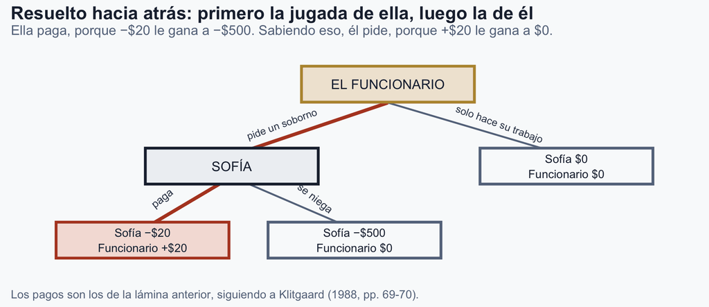

Figura 1

**Mejor respuesta** — la opción que más te conviene, tomando como dada la decisión del otro. Él pide porque ya puede ver cuál será la mejor respuesta de ella.

## Tres razones por las que las empresas pagan

- *“Paga $20 y te lo sello hoy.”*
- *“Págame y me aseguro de que ganes el contrato.”*
- *“Págame y olvido el impuesto que debes.”*

Dinero para agilizar · Comprar una ventaja · Comprar que no se aplique la ley

Categorías siguiendo a Rose-Ackerman (1978, cap. 1) y Shleifer & Vishny (1993, pp. 601, 604).

## El jefe no puede verlo todo

- Una ministra no puede inspeccionar cada cargamento en persona.
- Por eso contrata funcionarios que lo hagan por ella.
- El funcionario está en la frontera. Ella no.
- Él sabe qué pasó. Ella lee un resumen.

La persona en quien confías para hacer el trabajo puede usar el trabajo para sí misma.

## Jefe, funcionario, empresa

```
%%{init: {"fontSize":18,"theme":"base","themeVariables":{"fontSize":"18px","fontFamily":"Arial, Helvetica, sans-serif","primaryColor":"#eef1f4","primaryTextColor":"#1e293b","primaryBorderColor":"#334155","lineColor":"#334155","textColor":"#334155","edgeLabelBackground":"#f9fafb"},"flowchart":{"htmlL…
flowchart LR
  P["EL JEFE<br/>la ministra<br/>(principal)"]
  A["EL FUNCIONARIO<br/>el agente aduanal<br/>(agente)"]
  C["LA EMPRESA<br/>Sofía<br/>(cliente)"]
  P -->|"le da el encargo"| A
  A -->|"atiende"| C
  C -.->|"soborno"| A
  A -.->|"reporta"| P
  classDef principal fill:#e3ece9,stroke:#4a7c6f,stroke-width:3px,color:#1e293b;
  classDef agent fill:#f0e6d6,stroke:#b7943a,stroke-width:3px,color:#1e293b;
  classDef client fill:#eef1f4,stroke:#334155,stroke-width:2px,color:#1e293b;
  class P principal;
  class A agent;
  class C client;
```

Fuente: el modelo principal–agente–cliente de Klitgaard (1988, pp. 69–73). Las flechas punteadas son lo que el jefe no puede ver con facilidad.

## Lo que gana, lo que podría perder

**Lo que gana el funcionario**

- El soborno: **$20**.

**Lo que podría perder el funcionario**

- Probabilidad de que lo atrapen: **1 de cada 10**.
- Multa si lo atrapan: **$100**.
- Así que, en promedio, el riesgo le cuesta **$10**.

$20 ganados contra $10 que espera perder. Acepta el soborno.

## ¿Cuándo es demasiado riesgoso el soborno?

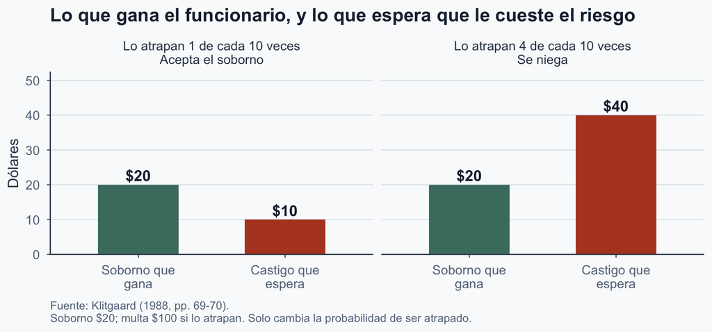

Figura 2: Se niega en cuanto el castigo esperado — la probabilidad de que lo atrapen multiplicada por la multa — rebasa el soborno.

## ¿Y qué?

- Sofía paga porque negarse le cuesta más.
- El funcionario pide porque el riesgo se ve pequeño.
- No hace falta suponer que alguno sea especialmente perverso.
- Cambia esos números y cambia la conducta.

# III. Tres señales de alerta de riesgo de corrupción

## Tres señales de alerta de riesgo de corrupción

- **Sin alternativa.** ¿Puede el ciudadano ir a otro lado?
- **Reglas poco claras.** ¿Puede el funcionario decidir casi cualquier cosa?
- **Nadie revisa.** ¿Alguien se va a enterar, y va a actuar?

El cruce fronterizo de Sofía sale mal en las tres.

## Las tres señales en la frontera

A qué te dirige cada señal de alerta

| Señal de alerta | La pregunta | En el cruce de Sofía |
| --- | --- | --- |
| Monopolio | ¿Puede ir a otro lado? | Un carril, un funcionario en turno |
| Discrecionalidad | ¿Quién decide, y con qué base? | Él elige qué camiones abrir |
| Rendición de cuentas | ¿Quién revisa, y qué sigue? | Sin registros, sin rotación, sin apelación |

Fuente: Klitgaard (1988, pp. 74–75, y recuadro 15, p. 88).

## Ejercicio 1 · Leer la oficina

Una oficina municipal expide licencias para puestos de comida. Un solo inspector cubre todo el mercado. Él decide si un puesto está “suficientemente limpio”. Anota el resultado en un formato de papel que guarda en su escritorio.

1. En esa descripción se esconden tres señales de alerta. Nómbrenlas.
2. ¿Cuál de las tres es la más peligrosa aquí — y por qué esa?

5 minutos · una pareja reporta, las demás dicen en qué no coinciden

## ¿Dejar que los funcionarios elijan siempre es malo?

- “Reglas poco claras” dice que un funcionario no debería decidir libremente.
- Pero quieres que el puente lo construya quien sepa construirlo.
- La oferta más barata no siempre viene de la mejor constructora.
- Entonces: ¿dejar que elijan deja entrar empresas más sucias?

Decarolis, Fisman, Pinotti & Vannutelli (2025, pp. 214–216). Más de 200,000 contratos de obra pública en Italia, 2000–2016.

## La discrecionalidad es mucho menos peligrosa cuando la competencia se mantiene fuerte

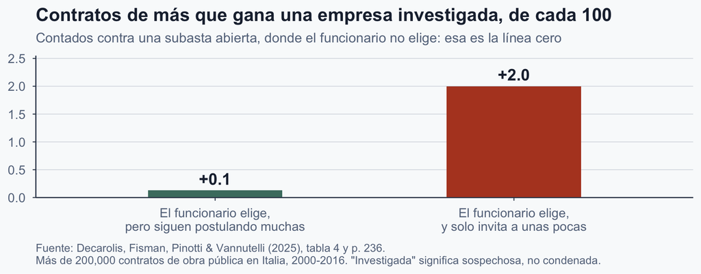

Figura 3: Elegir, por sí solo: casi ningún cambio. Elegir con pocos postores: dos contratos más de cada cien.

En estos contratos, dejar que un funcionario eligiera al ganador importó poco — siempre que muchas empresas siguieran pudiendo competir.

## Revisar a todos es caro

- Auditores, inspectores, cámaras y tribunales cuestan dinero.
- Perseguir el último soborno pequeño cuesta más de lo que ahorra.
- La versión franca de Klitgaard: la cantidad óptima no es cero.
- Así que dirige el esfuerzo a donde el daño es mayor.

Fuente: Klitgaard (1988, cap. 2, pp. 24–27). Lo plantea como un punto presupuestal, no como una excusa.

## ¿Y qué?

- Tres señales de alerta te dejan inspeccionar cualquier oficina.
- Dejar que los funcionarios elijan no es el peligro en sí.
- Elegir sin competencia sí es el peligro.
- Ahora: ¿y si Sofía enfrenta a más de un funcionario?

# IV. ¿Un soborno o muchos?

## Soborno cuando al Estado sí le pagan

Él registra el cargamento y cobra los $100, tal como dicen las reglas. Esa tarifa no la puede perdonar — pero sí decide *cuándo* sale la mercancía. Los $20 compran hoy en vez de la semana que entra.

Sofía paga la tarifa legal, y encima un soborno (dólares)

| Quién | Monto |
| --- | --- |
| Sofía paga en total | $120 |
| El gobierno recibe | $100 |
| El funcionario se queda con | $20 |

- Sofía sale $20 peor que si se hubieran seguido las reglas.
- Tiene motivo para quejarse.

## Soborno cuando al Estado no le llega nada

Esta vez no anota el cargamento en ninguna parte. Sin registro, nunca se cobra la tarifa de $100. Deja pasar el camión y se queda con $60.

El funcionario no anota nada y se queda con todo (dólares)

| Quién | Monto |
| --- | --- |
| Sofía paga en total | $60 |
| El gobierno recibe | $0 |
| El funcionario se queda con | $60 |

- Sofía paga $60 en vez de $100. Está **mejor**.
- Ahora nadie en la sala quiere quejarse.

## A dónde va el dinero

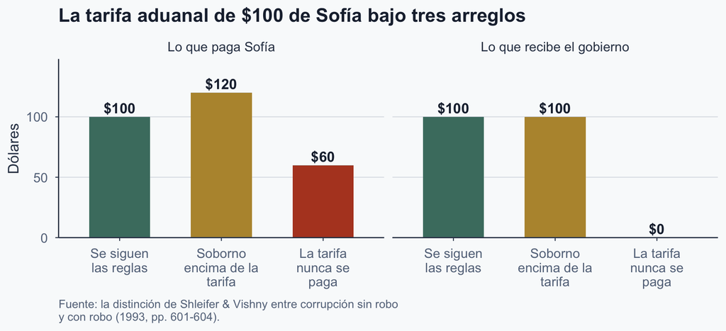

Figura 4: Cuando la tarifa se salta, el perdedor es el erario — y el erario no está presente.

## Por qué casi nadie lo denuncia

- Cuando la tarifa se salta, Sofía también ahorra.
- Un importador honesto que paga $100 queda en desventaja.
- Para sobrevivir, tiene que buscar su propio funcionario amable.
- Ahora los dos lados quieren lo mismo: silencio.

Cuando al Estado le roban, los dos lados salen ganando — así que a los dos les conviene el silencio.

Fuente: Shleifer & Vishny (1993, p. 604). Su remedio: primero, hacer visible en las cuentas el robo al Estado.

## Sesenta peajes en el Rin

Un comerciante navega río abajo. Sesenta señores distintos lo detienen y le cobran peaje.

- ¿Qué le pasa al precio final?
- ¿Quién deja de hacer el viaje por completo?

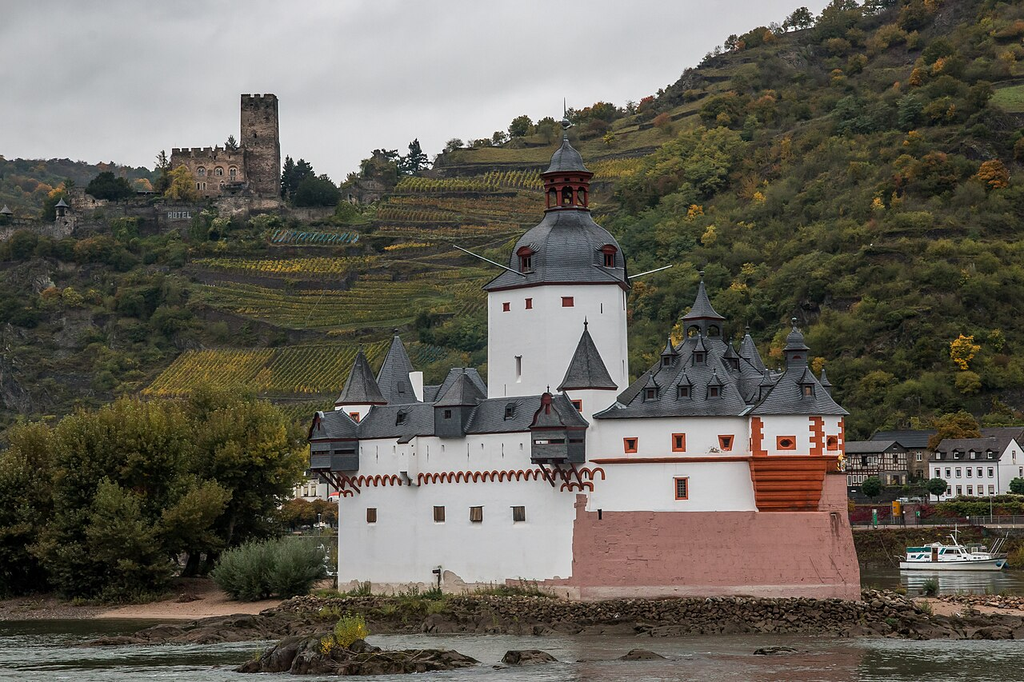

Pfalzgrafenstein, estación de peaje construida en medio del Rin en Kaub (desde 1326). Foto © Gary Bembridge, [CC BY 2.0](https://creativecommons.org/licenses/by/2.0/), vía Wikimedia Commons.

Hacia 1400 el Rin tenía unos 60 peajes independientes; los ríos ingleses, ninguno. Reportado en Shleifer & Vishny (1993, p. 608), citando a Heilbroner (1962).

## Tres formas de acomodar las oficinas

```
%%{init: {"fontSize":19,"theme":"base","themeVariables":{"fontSize":"19px","fontFamily":"Arial, Helvetica, sans-serif","primaryColor":"#eef1f4","primaryTextColor":"#1e293b","primaryBorderColor":"#334155","lineColor":"#334155","textColor":"#334155","edgeLabelBackground":"#f9fafb"},"flowchart":{"htmlL…
flowchart LR
  A1["CUALQUIERA SIRVE<br/>dos oficinas,<br/>cualquiera aprueba"] --> A2["Soborno casi cero<br/>Pasa casi todo el comercio"]
  B1["UNA OFICINA<br/>una oficina aprueba<br/>todo de una vez"] --> B2["Un soborno mediano<br/>Pasa algo de comercio"]
  C1["TODAS DEBEN ACEPTAR<br/>cinco oficinas,<br/>cada una puede frenarla"] --> C2["Soborno tras soborno<br/>Pasa el mínimo comercio"]
  classDef good fill:#e3ece9,stroke:#4a7c6f,stroke-width:3px,color:#1e293b;
  classDef mid fill:#f0e6d6,stroke:#b7943a,stroke-width:3px,color:#1e293b;
  classDef bad fill:#f4e0da,stroke:#b44527,stroke-width:3px,color:#1e293b;
  class A1,A2 good;
  class B1,B2 mid;
  class C1,C2 bad;
```

Fuente: Shleifer & Vishny (1993, sec. III, pp. 604–608). Los peajes del Rin son el tercer caso.

## Cuando cualquier oficina puede decir que no

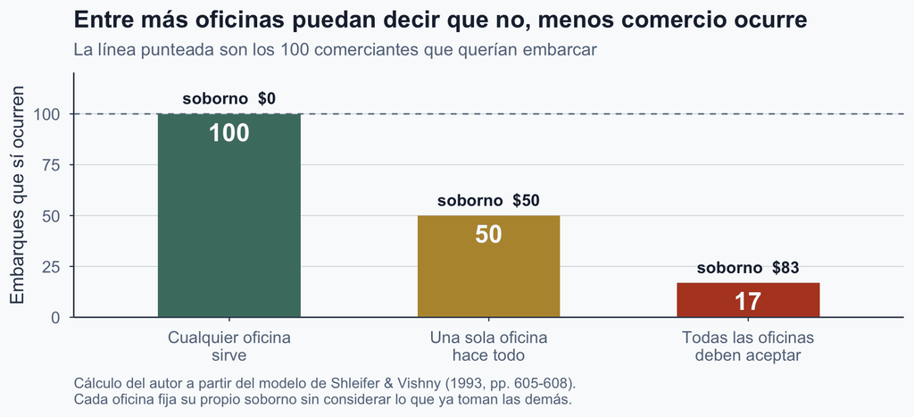

Figura 5: Cada oficina agrega su propia exigencia: el comerciante paga más y menos embarques valen la pena.

## Ejercicio 2 · Un solo río

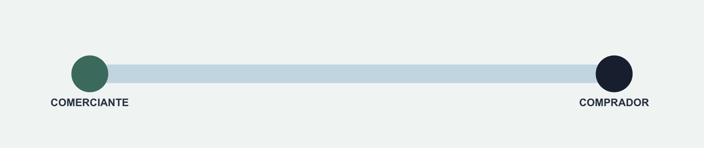

Figura 6

Una comerciante, un río. Su carga vale una cantidad entre **$1 y $100** — está en mi tarjeta, y ustedes no la ven.

Ella se entera de cuánto suman los peajes **antes** de zarpar. Así que es el viaje completo o ninguno.

Peajes **por debajo** de la tarjeta → navega → todos los peajes se cobran  
Peajes **por encima** → se regresa → **nadie cobra nada**

## Primero: una sola caseta

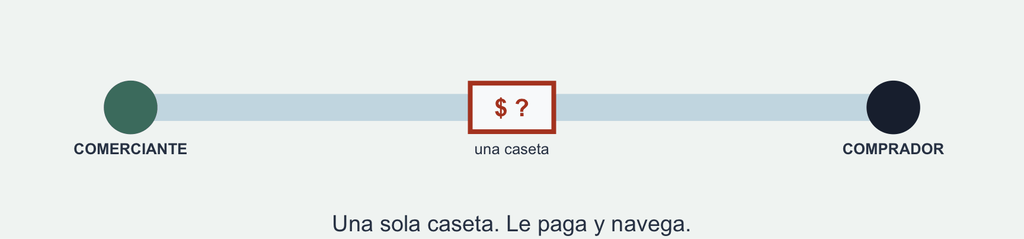

Figura 7

**¿Cuánto debería cobrar?**

Demasiado y ella se regresa sin pagar nada. Muy poco y dejaste dinero sobre la mesa. La mejor respuesta es como **$50** — ella navega más o menos la mitad de las veces.

## Ahora un peaje por equipo

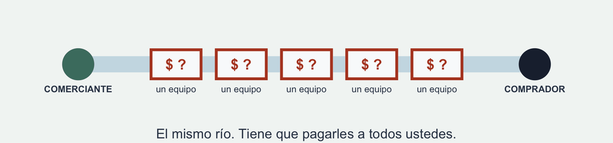

Figura 8

**El mismo río. La misma comerciante. Cambió una cosa:** ahora tiene que pasar por todos ustedes.

Su equipo es una caseta. **Escriban su peaje. No lo enseñen. No hablen con los otros equipos.**

Revelamos juntos y los sumamos. **Esto lo jugamos dos veces.**

## Escenario 1 · El barco pasa

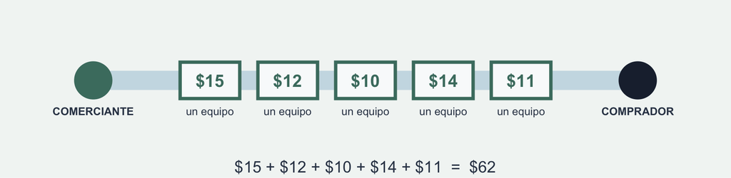

Figura 9

La tarjeta decía **$72**. Los peajes sumaron **$62**.

Navega — y todos los equipos cobran.

## Escenario 2 · El barco se regresa

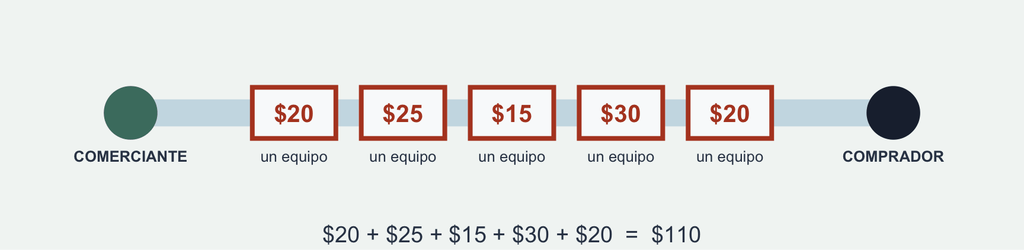

Figura 10

La tarjeta decía **$72**. Los peajes sumaron **$110**.

Se regresa — y nadie cobra. Ni un solo equipo.

## ¿Y qué?

- Repartir la corrupción entre muchas manos la empeora.
- Las muchas oficinas incluso recaudan menos en total.
- Una segunda oficina que expida el mismo permiso recorta el poder de monopolio.
- Las elecciones y una prensa libre actúan sobre la rendición de cuentas, no sobre el monopolio.

Fuente: Shleifer & Vishny (1993, pp. 605–611). Nota su advertencia incómoda sobre las reformas de descentralización.

## Cinco preguntas para cualquier oficina

1. **Monopolio** — ¿qué controla el funcionario, y puede el ciudadano ir a otro lado?
2. **Discrecionalidad** — ¿quién decide, y con base en qué regla escrita?
3. **Rendición de cuentas** — ¿quién puede enterarse, y quién puede sancionar?
4. **Robo** — ¿al Estado le siguen pagando, o la tarifa desaparece?
5. **Muchas manos** — ¿cuántos funcionarios pueden frenar la misma gestión?

La corrupción no es solo cuestión de gente mala. Es cuestión de **diseño institucional**.

## Referencias

Decarolis, F., Fisman, R., Pinotti, P., & Vannutelli, S. (2025). Rules, discretion, and corruption in procurement: Evidence from Italian government contracting. *Journal of Political Economy Microeconomics, 3*(2), 213–254. https://doi.org/10.1086/732654

Heilbroner, R. L. (1962). *The making of economic society*. Prentice-Hall.

Klitgaard, R. (1988). *Controlling corruption*. University of California Press.

## Referencias (continuación)

Rose-Ackerman, S. (1978). *Corruption: A study in political economy*. Academic Press.

Shleifer, A., & Vishny, R. W. (1993). Corruption. *The Quarterly Journal of Economics, 108*(3), 599–617. https://doi.org/10.2307/2118402